# Machine Learning Engineer Nanodegree

## Project: Lyrics Sentiment Analysis

Can we predict the genre of one song just analysing the lyrics? What are the most frequent words used for each genre? Which are the positive and negative words in each genre? What are the overall sentiments expressed by a music genre?

The goal of this project is to apply supervised Machine learning to predict what is the genre of a specific song.

This is a text classification problem. Machine Learning uses Natural Processing Language (NPL),classifying data based on past observations by using labels examples in the training data, so that the machine learning algorithms can learn.

I got the idea for this project looking at some projects for text classification problems such as, “Spam Detection” and “Movies review”, below some examples:

https://medium.com/@martinpella/naive-bayes-for-sentiment-analysis-49b37db18bf8

https://towardsdatascience.com/sentiment-analysis-with-python-part-1-5ce197074184?gi=eb8658aa284

https://towardsdatascience.com/spam-classifier-in-python-from-scratch-27a98ddd8e73

First we scrape the data, then prepare our dataset by removing punctuation, numbers and also change all the text to lower case. After that, we will tokenize and lemmatize our lyrics. After that, we can use Word Cloud to check the most frequent words used in each genre. To solve the problem we will use Supervised Learning techniques/algorithms, such as Naive Bayes Multinomial, Logistic Regression and Support Vector Machine to classify the song genre, given its lyrics. To see if the model is working well, the data will be split into training set and test set; to check the accuracy of the model, the training set will be 80% and the test set 20%. To evaluate the performance, we will check the Accuracy, Precision, Recall and F1 score metrics. Finally, we will perform the hyperparameter tuning to improve the accuracy of the best model.

## Getting Started

The dataset was taken from Genius by using the [python wrapper for the Genius API](https://www.johnwmillr.com/scraping-genius-lyrics/).

To decide which songs to take I checked what are the top 20 artists/bands of all times, for each genre:

[Country](https://www.billboard.com/charts/greatest-country-artists)

[Hard-Rock](https://www.ranker.com/list/best-hard-rock-bands-and-artists/reference)

[Rap](https://www.ranker.com/crowdranked-list/the-greatest-rappers-of-all-time)

Then I chose the 50 most popular songs from those artists.

For a better analysis I replaced the only instrumental songs with songs with lyrics.

In total, the dataset has 3000 samples and 1000 samples by genre.

## Exploring the data

```python
# Import libraries necessary for this project
import pandas as pd
import numpy as np

# Allows the use of display() for DataFrames
from IPython.display import display

# Pretty display for notebooks
import matplotlib.pyplot as plt
%matplotlib inline
import seaborn as sb

#Display markdown formatted output
from IPython.display import Markdown


#ignore warnings
import warnings
warnings.filterwarnings('ignore')
```

```python
#load the lyrics dataset
all_lyrics=pd.read_csv('lyrics.csv')

#preview the first 2 lines of the dataset
all_lyrics.head(2)
```

|  | artist | lyrics | title |
| --- | --- | --- | --- |
| 0 | 50 Cent | [Produced by Dirty Swift]\n\n[Intro: 50 Cent]\... | 21 Questions |
| 1 | 50 Cent | [Intro]\nFifty, fifty\nFifty, fifty\nFifty, fi... | 9 Shots |

```python
#information about the dataset
all_lyrics.info()
```

```
<class 'pandas.core.frame.DataFrame'>
RangeIndex: 3000 entries, 0 to 2999
Data columns (total 3 columns):
artist    3000 non-null object
lyrics    3000 non-null object
title     3000 non-null object
dtypes: object(3)
memory usage: 70.4+ KB
```

**The all_lyrics dataset contains 3000 samples with the following columns:**

**artist:** The name of the singer / band.

**lyrics:** The lyrics of the song.

**title:** The title of the song.

## Data Preparing / Cleaning

**Adding the column genre**

Our dataset is missing a label that is the genre of the songs, we need to add the column genre. First, let's check the artists names that we have in our dataset.

```python
def bold (string):
    display (Markdown (string))
bold('**List of Artists:**')

#getting the list of the artists
all_lyrics.artist.unique()
```

**List of Artists:**

```
array(['50 Cent', 'AC/DC', 'Aerosmith', 'Alan Jackson', 'Alice Cooper',
       'Alice in Chains', 'Beastie Boys', 'Big Sean', 'Blue Öyster Cult',
       'Bon Jovi', 'Buck Owens', 'Busta Rhymes', 'Charley Pride',
       'Conway Twitty', 'Deep Purple', 'Def Leppard', 'DMX',
       'Dolly Parton', 'Dr.\xa0Dre', 'Drake', 'Eminem', 'Garth Brooks',
       'George Jones', 'George Strait', 'Guns N’ Roses',
       'Hank Williams Jr.', 'Ice Cube', 'J. Cole', 'JAY-Z', 'Johnny Cash',
       'Kanye West', 'Kendrick Lamar', 'Kenny Chesney', 'Kenny Rogers',
       'Kiss', 'Led Zeppelin', 'Lil Wayne', 'LL Cool J', 'Loretta Lynn',
       'Ludacris', 'Merle Haggard', 'Metallica', 'Method Man', 'Motörhead',
       'Nas', 'Ozzy Osbourne', 'Reba McEntire', 'Ronnie Milsap', 'Rush',
       'Scorpions', 'Snoop Dogg', 'The Notorious B.I.G.', 'Tim McGraw',
       'Van Halen', 'Waylon Jennings', 'Willie Nelson', 'ZZ Top', 'Queen',
       'Alabama', 'Jimi Hendrix'], dtype=object)
```

Adding the column "Genre" containing the genre of each artist:

```python
#adding a column genrer
def genre(all_lyrics):
   if all_lyrics['artist'] in ('LL Cool J','Beastie Boys','50 Cent','Drake','Big Sean', 'Busta Rhymes', 'DMX', 'Dr.\xa0Dre', 'Eminem', 'Ice Cube', 'J. Cole', 'JAY-Z', 'Kanye West', 'Kendrick Lamar','Lil Wayne','Ludacris','Method Man', 'Nas', 'Snoop Dogg', 'The Notorious B.I.G.'):
      return 'Rap'
   elif all_lyrics['artist'] in ('Bon Jovi','Queen','Jimi Hendrix','Kiss','AC/DC','Aerosmith','Alice Cooper','Alice in Chains', 'Blue Öyster Cult', 'Def Leppard', 'Deep Purple',"Guns N’ Roses",'Led Zeppelin', 'Metallica', 'Motörhead', 'Ozzy Osbourne', 'Rush', 'Scorpions', 'Van Halen','ZZ Top'):
      return 'Rock'
   else:
    return 'Country'

all_lyrics['genre']=all_lyrics.apply(genre,axis=1)
```

```python
#preview the first 2 lines of the dataset
all_lyrics.head(2)
```

|  | artist | lyrics | title | genre |
| --- | --- | --- | --- | --- |
| 0 | 50 Cent | [Produced by Dirty Swift]\n\n[Intro: 50 Cent]\... | 21 Questions | Rap |
| 1 | 50 Cent | [Intro]\nFifty, fifty\nFifty, fifty\nFifty, fi... | 9 Shots | Rap |

```python
#preview the last 2 lines of the dataset
all_lyrics.tail(2)
```

|  | artist | lyrics | title | genre |
| --- | --- | --- | --- | --- |
| 2998 | Jimi Hendrix | They don't know \nThey don't know \nLike I k... | Who Knows | Rock |
| 2999 | Jimi Hendrix | Well, you've got me floatin' around and 'round... | You've Got Me Floating | Rock |

```python
#count the number of songs by genre
all_lyrics.genre.value_counts().head()
```

```
Rock       1000
Rap        1000
Country    1000
Name: genre, dtype: int64
```

Now, we have the column genre and we can see that we have 1000 samples by genre.

**Cleaning the data**

Let's print a sample of our lyrics feature and check how messy it is:

```python
sample = all_lyrics.iloc[1200]['lyrics']
print(sample)
```

```
[Verse 1]
I've been thinking about
Thinking 'bout sex
Always hungry for something that I haven't had yet
Well, maybe, baby, you got something to lose
Well, I got something I, got something for you

[Chorus]
My way, your way, anything goes tonight
My way, your way, anything goes to

[Verse 2]
Panties round your knees
With your ass in debris
Doing that grind with a push and a squeeze
Tied up, tied down, up against the wall
Be my rubber made, baby, and we can do it all

[Chorus]
My way, your way, anything goes tonight
My way, your way, anything goes tonight-i-i-i-i, yeah-yeah
My way, your way, anything goes tonight
My way, your way, anything goes tonight!

[Guitar Solo]

[Chorus]
My way, your way, anything goes tonight
My way, your way, anything goes tonight, oh yeah
My way, your way, anything goes tonight-ay-ay-ay-ay, yeah
My way, your way, anything goes tonight
My way, your way, anything goes tonight

[Outro]
Tonight, tonight, tonight
Anything goes tonight
Oh woah woah woah, woah...
Said anything goes tonight
```

Looking at our lyrics feature, we can see that we have some lyrics extra words that may disrupt our analysis, like "Verse" and "Chorus", therefore before starting our analysis we must get rid of them. Besides, we are also going to convert our text to lowercase, remove the brackets and the digits.

```python
import string

# removing the newline regexp
all_lyrics['lyrics'] = all_lyrics['lyrics'].replace('\n',' ', regex=True)

#removing everything inside the brackets
all_lyrics['lyrics'] = all_lyrics['lyrics'].str.replace(r'[\(\[].*?[\)\]]', '')

#converting to lower case
all_lyrics.lyrics = all_lyrics.lyrics.apply(lambda x: x.lower())

#removing digits
all_lyrics.lyrics = all_lyrics.lyrics.apply(lambda x: x.translate(str.maketrans('','',string.digits)))
```

Lets see now, how our samples looks like:

```python
sample_clean = all_lyrics.iloc[1200]['lyrics']
print(sample_clean)
```

[output not shown]

Much better! But we still have a lot of punctuation and stopwords, common words which we want to ignore for our analysis, such as “I”, The”, “Or”, etc. We will not need to remove all of them manually since we will be using the wordcloud package, which is very comprehensive regarding punctuation and stopwords.

For now, we will generate a wordcloud sample and check if our feature lyrics is clean enough to proceed with our analysis.

```python
#import wordcloud
from os import path
from PIL import Image
from wordcloud import WordCloud, STOPWORDS, ImageColorGenerator
```

```python
# Groupby by genre
genre = all_lyrics.groupby('genre')
```

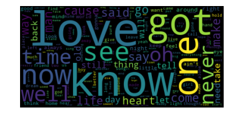

```python
# Join all lyrics of each of country genre:
country = " ".join(all_lyrics for all_lyrics in all_lyrics[all_lyrics['genre']=='Country'].lyrics)

# basic wordcloud generation
wordcloud = WordCloud().generate(country)
plt.imshow(wordcloud, interpolation='bilinear')
plt.axis("off")
plt.show()
```

Our word cloud is quite nice but if we look carefully, you can see that the words aggregation isn't really optimal yet. For example, in our word cloud we have the word "said", that for a better analysis should be recognized as belonging to the "say" root. We call this **lemmatization** . The word cloud package applies only plural normalization, this means that the algorithm only removes the plural "s" from the words.

**Token and Lemmatization**

Lemmatization is a text normalization technique used in Natural Language Processing (NPL) to prepare the text for future analysis. As already discussed, lemmatization recognize a given words in its root. This means that when we use lemmatization we remove all verbs suffixes ("-ing", "-ed"), for example, the words “playing” and “played” will be both recognized as “play”. There are different algorithms for lemmatization, in this project we are going to use WordNetLemmatizer.

To use lemmatization first we need to tokenize the text. Tokenization will break down a text into words. If we don't use the tokenization the algorithm WordNetLemmatizer will lemmatize the entire sentence as a word.

```python
#join all lyrics by genre
rap = " ".join(lyrics for lyrics in all_lyrics[all_lyrics['genre']=='Rap'].lyrics)
country = " ".join(lyrics for lyrics in all_lyrics[all_lyrics['genre']=='Country'].lyrics)
rock = " ".join(lyrics for lyrics in all_lyrics[all_lyrics['genre']=='Rock'].lyrics)
```

```python
import nltk
from nltk import word_tokenize

#tokenizing the lyrics by genre
tokens_rap = nltk.tokenize.word_tokenize(rap)
tokens_country = nltk.tokenize.word_tokenize(country)
tokens_rock = nltk.tokenize.word_tokenize(rock)
```

```python
#import WordNetLemmatizer
from nltk.stem.wordnet import WordNetLemmatizer
wnl = WordNetLemmatizer()

#lemmatize the tokens lyrics by genre
lemmatized_rap = [wnl.lemmatize(word, 'v') for word in tokens_rap]
lemmatized_country = [wnl.lemmatize(word, 'v') for word in tokens_country]
lemmatized_rock = [wnl.lemmatize(word, 'v') for word in tokens_rock]
```

Words like "I'm", "you're" were tokenized and were cut as "I", "m", "you", "re", this is not good for our analyses, then we are going to remove the 1 or 2 letters words:

```python
import re
#select 1 or 2 letters words
shortword = re.compile(r'\W*\b\w{1,2}\b')

#remove the 1 or 2 letters words
joined_rap = " ".join(lemmatized_rap)
join_rap = shortword.sub('', joined_rap)

joined_country = " ".join(lemmatized_country)
join_country = shortword.sub('', joined_country)

joined_rock = " ".join(lemmatized_rock)
join_rock = shortword.sub('', joined_rock)
```

Also the English slang "gonna" and "wanna", had been tokenized as "gon", "na". In this case we are going to replace "gon" for "go" and "wan" for "want".

The lemma also did not recognize fuckin as fuck, then we will do that as below:

```python
#replace english slang
lyrics_rap = join_rap.replace("gon ", "go").replace("wan ", "want").replace("fuckin ", "fuck")
lyrics_country = join_country.replace("gon ", "go").replace("wan ", "want")
lyrics_rock = join_rock.replace("gon ", "go").replace("wan ", "want")
```

Let's see how our word cloud sample looks like now.

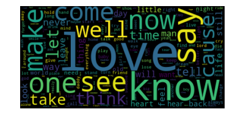

```python
# basic wordcloud generation
text = lyrics_country
wordcloud = WordCloud().generate(text)
plt.imshow(wordcloud, interpolation='bilinear')
plt.axis("off")
plt.show()
```

As we can see, the word “said” isn't in the word cloud anymore, this means that it was recognized as “say” as per lemmatization step. So, our lyrics are ready to start the analyses. get analysed.

## Exploration Text Analysis

What are the most frequent words used for each genre? Which are the positive and negative words in each genre? The next steps are going to answer those questions.

As mentioned earlier, we will make our analysis with WordCloud package. Word Cloud is a cloud filled with lots of words in different sizes, which represent the frequency of each word.

To make our word cloud nicer, we will change some parameters, like color and shape.

**The most frequent words used by Country songs**

**Country Word Cloud:**

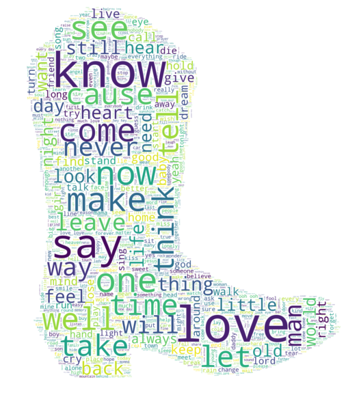

```python
#select a mask for country genre
country_mask = np.array(Image.open("C:\\Users\\jesus\\Desktop\\img\\boots.jpg"))

#word cloud parameters
wc = WordCloud(background_color="white", max_words=10000, mask= country_mask, random_state=42)

# Generate a wordcloud
wc.generate(lyrics_country)

bold('**Country Word Cloud:**')

# show
plt.figure(figsize=[20,10])
plt.imshow(wc, interpolation='bilinear')
plt.axis("off")
plt.show()
image_colors = ImageColorGenerator(country_mask)
```

We can see that country mentions "love" frequently, and uses “know” a lot, followed by words as “come”, “think”, “make”, “say” and so on.

**The most frequent words used by Rock songs**

**Rock Word Cloud:**

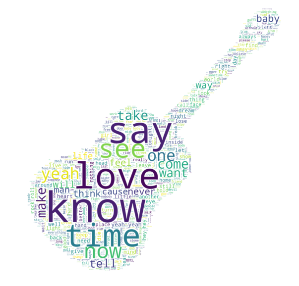

```python
#select a mask for country genre
rock_mask = np.array(Image.open("C:\\Users\\jesus\\Desktop\\img\\rock.jpg"))

wc = WordCloud(background_color="white", max_words=10000, mask= rock_mask, random_state=42)

# Generate a wordcloud
wc.generate(lyrics_rock)

bold('**Rock Word Cloud:**')

# show
plt.figure(figsize=[20,10])
plt.imshow(wc, interpolation='bilinear')
plt.axis("off")
plt.show()
image_colors = ImageColorGenerator(rock_mask)
```

The most frequent words used by rock are quite similar to country. Here we have a lot of “love” and “know”. And also “say” appears frequently. The words “time”, “now”, “come”, “want”, “baby” appear with quite some frequency too.

**The most frequent words used by Rap songs**

**Rap Word Cloud:**

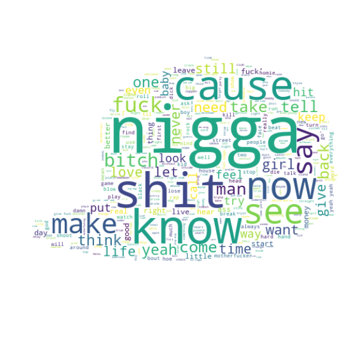

```python
#select a mask for rap genre
rap_mask = np.array(Image.open("C:\\Users\\jesus\\Desktop\\img\\cap_.jpg"))

wc = WordCloud(background_color="white", max_words=10000,mask=rap_mask, random_state=42)

# Generate a wordcloud
wc.generate(lyrics_rap)

bold('**Rap Word Cloud:**')

# show
plt.figure(figsize=[20,10])
plt.imshow(wc, interpolation='bilinear')
plt.axis("off")
plt.show()
image_colors = ImageColorGenerator(rap_mask)
```

The rap word cloud is very different from the ones for country and rock. Here we have very offensives words that appear with high frequency.

**Word Count**

Another interesting data to look into could be how many words a song has on average, per genre: is rap the genre using the biggest number of words, or is it country? How do they stack against each other? Let’s analyse our dataset to find out.

```python
#function to count the words
def word_count(text_string):
    '''Calculate the number of words in a string'''
    return len(text_string.split())
```

```python
#insert a column word_count in our dataset
all_lyrics['word_count'] = all_lyrics['lyrics'].apply(word_count)

#the statics for word_count
all_lyrics['word_count'].describe()
```

```
count    3000.000000
mean      353.906667
std       246.815384
min        31.000000
25%       173.000000
50%       256.000000
75%       508.000000
max      2158.000000
Name: word_count, dtype: float64
```

The mean of the words per song of our dataset is 353 and the maximum is 2158. Let's check now, which genre has more words:

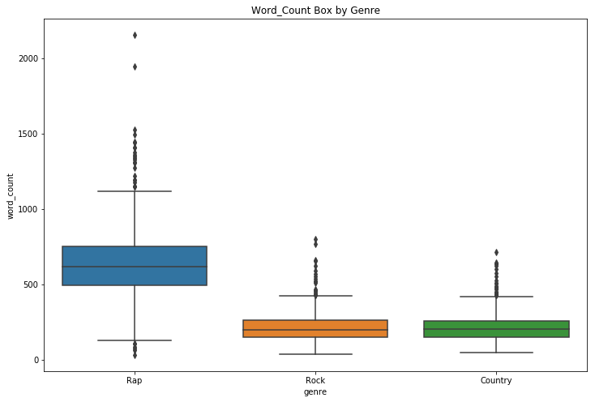

```python
#boxplot graph
f,ax = plt.subplots(figsize = (12,8))

sb.boxplot (x='genre', y='word_count', data=all_lyrics)

ax.set_title('Word_Count Box by Genre')
```

As we expected rap has uses the most words. And, country and rock have very similar number of words by song.

**Positive and Negative Lyrics**

To decide if a song is more positive or negative, we will use the Afinn algorithm. Afinn scores in a range between -5 (negative) and +5 (positive). First Afinn preprocessed the text by removing the punctuation and converting to lowercase then it assign the score.

```python
#import afinn
from afinn import Afinn

#set the language to English
afinn = Afinn(language='en')

bold('**Affin Score example for love:**')

#affin score example
afinn.score('love.')
```

**Affin Score example for love:**

```
3.0
```

```python
#adding the column afinn_score in our dataset
all_lyrics['afinn_score'] = all_lyrics['lyrics'].apply(afinn.score)
```

```python
#affin_score statics
all_lyrics['afinn_score'].describe()
```

```
count    3000.000000
mean      -12.982667
std        53.725896
min      -726.000000
25%       -22.000000
50%         0.000000
75%        14.000000
max       166.000000
Name: afinn_score, dtype: float64
```

When we apply Afinn in a long text this may get higher score, just because it contains more words. To fix it, we are going to add the column afinn_adjusted that is the result of afinn_score divided by the count of words.

```python
#adding the column afinn_adjusted in our dataset
all_lyrics['afinn_adjusted'] = all_lyrics['afinn_score'] / all_lyrics['word_count'] * 100

#affin_score statics
all_lyrics['afinn_adjusted'].describe()
```

```
count    3000.000000
mean       -0.496870
std        12.090328
min      -100.409836
25%        -6.705339
50%         0.000000
75%         6.060606
max        73.451327
Name: afinn_adjusted, dtype: float64
```

```python
#columns to display
columns_to_display = ['artist', 'lyrics','title','genre','afinn_adjusted']
```

```python
#set the most negative songs
all_lyrics.sort_values(by='afinn_adjusted')[columns_to_display].head(3)
```

|  | artist | lyrics | title | genre | afinn_adjusted |
| --- | --- | --- | --- | --- | --- |
| 361 | Big Sean | ass, ass, ass, ass, ass ass, ass, ass, ass,... | Dance (A$$) | Rap | -100.409836 |
| 2506 | Snoop Dogg | fuck them other niggas 'cause i'm down for my... | Down 4 My Niggas | Rap | -88.536585 |
| 2171 | Motörhead | if you squeeze my lizard i'll put my snake on ... | Killed by Death | Rock | -71.597633 |

```python
#set the most positive songs
all_lyrics.sort_values(by='afinn_adjusted')[columns_to_display].tail(3)
```

|  | artist | lyrics | title | genre | afinn_adjusted |
| --- | --- | --- | --- | --- | --- |
| 1146 | George Jones | when with the savior we enter the glory land w... | Won't It Be Wonderful There? | Country | 54.248366 |
| 2935 | Alabama | yes, jesus loves me yes, jesus loves me ye... | Jesus Loves Me | Country | 68.907563 |
| 2857 | Queen | funny how love is everywhere just look and see... | Funny How Love Is | Rock | 73.451327 |

```python
#affin_score statics by genre
all_lyrics.groupby('genre')['afinn_adjusted'].describe()
```

| genre | count | mean | std | min | 25% | 50% | 75% | max |
| --- | --- | --- | --- | --- | --- | --- | --- | --- |
| Country | 1000.0 | 5.408293 | 9.904624 | -41.200000 | -0.476029 | 4.275790 | 10.110969 | 68.907563 |
| Rap | 1000.0 | -8.049333 | 11.009734 | -100.409836 | -14.082627 | -6.835487 | -0.662252 | 20.797227 |
| Rock | 1000.0 | 1.150429 | 11.170763 | -71.597633 | -4.104698 | 1.379376 | 7.153550 | 73.451327 |

Considering the mean of afinn_adjusted the Country genre has the most positive songs (5.40), while rap songs has the most negative songs (-8.04). Let's generate a boxplot graph to better visualize the results:

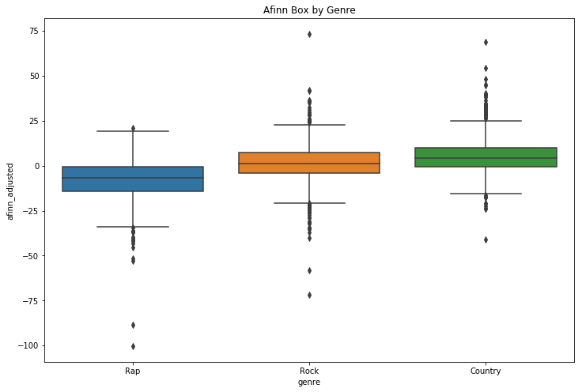

```python
#boxplot graph
f,ax = plt.subplots(figsize = (12,8))

sb.boxplot (x='genre', y='afinn_adjusted', data=all_lyrics)

ax.set_title('Afinn Box by Genre')
```

As mentioned, rap has the most negative songs, while country has the most positive songs. And, Country and Rock are quite similar.

Adding a "feelings" column. Where:

-Score <0 is negative

-Score = 0 is neutral

-Score >0 is positive

```python
#set the edges to cut
bin_edges = [-101,0,1,np.inf]

#set the labels
bin_names = ['negative', 'neutral', 'positive']

#adding the column feeling
all_lyrics['feelings'] = pd.cut (all_lyrics['afinn_adjusted'], bin_edges, labels = bin_names)

#display first 5 samples
all_lyrics.head()
```

|  | artist | lyrics | title | genre | word_count | afinn_score | afinn_adjusted | feelings |
| --- | --- | --- | --- | --- | --- | --- | --- | --- |
| 0 | 50 Cent | i just want to chill and twist the lye catc... | 21 Questions | Rap | 611 | 102.0 | 16.693944 | positive |
| 1 | 50 Cent | fifty, fifty fifty, fifty fifty, fifty ferrar... | 9 Shots | Rap | 359 | -34.0 | -9.470752 | negative |
| 2 | 50 Cent | she loves me, she loves me not yeah, she love... | A Baltimore Love Thing | Rap | 843 | 16.0 | 1.897983 | positive |
| 3 | 50 Cent | somethin' special, unforgettable cent, cen... | Ayo Technology | Rap | 716 | -3.0 | -0.418994 | negative |
| 4 | 50 Cent | it's easy to see when you look at me if you l... | Back Down | Rap | 722 | -69.0 | -9.556787 | negative |

Let’s check which are the most frequent words used in positives and negatives songs. For that, we are going to use word cloud once again. First, we need to tokenize and lemmatize the text.

```python
#join lyrics by feeling
positive = " ".join(lyrics for lyrics in all_lyrics[all_lyrics['feelings']=='positive'].lyrics)
negative = " ".join(lyrics for lyrics in all_lyrics[all_lyrics['feelings']=='negative'].lyrics)

#tokenizing the lyrics by feeling
tokens_positive = nltk.tokenize.word_tokenize(positive)
tokens_negative = nltk.tokenize.word_tokenize(negative)

#lematize the tokens by feeling
lemmatized_tokens_positive = [wnl.lemmatize(word, 'v') for word in tokens_positive]
lemmatized_tokens_negative = [wnl.lemmatize(word, 'v') for word in tokens_negative]

#remove the 1 or 2 letters words
joined_positive = " ".join(lemmatized_tokens_positive)
joined_negative = " ".join(lemmatized_tokens_negative)
lyrics_long_positive = shortword.sub('', joined_positive)
lyrics_long_negative = shortword.sub('', joined_negative)

#replace English slang
lyrics_positive = lyrics_long_positive.replace("gon ", "go").replace("wan ", "want")
lyrics_negative = lyrics_long_negative.replace("gon ", "go").replace("wan ", "want").replace("fuckin ", "fuck")
```

**Positive Word Cloud:**

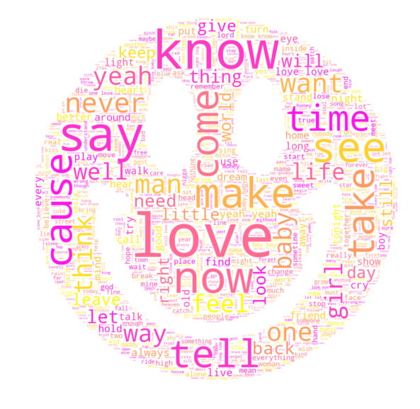

```python
#select mask for positive songs
positive_mask = np.array(Image.open("C:\\Users\\jesus\\Desktop\\img\\happyb.jpg"))

#set parameters for positive word cloud
wc = WordCloud(background_color="white", max_words=10000,colormap="spring", mask= positive_mask, random_state=42)

# Generate a wordcloud
wc.generate(lyrics_positive)

bold('**Positive Word Cloud:**')

# show
plt.figure(figsize=[20,10])
plt.imshow(wc, interpolation='bilinear')
plt.axis("off")
plt.show()
image_colors = ImageColorGenerator(positive_mask)
```

The words used most frequently in positive songs are : “know”, “love”, “say”, and “tell”.

**Negative Word Cloud:**

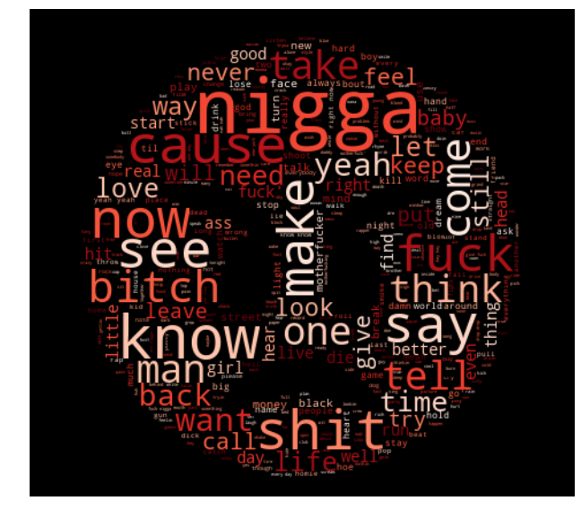

```python
#set parameters for negative word cloud
negative_mask = np.array(Image.open("C:\\Users\\jesus\\Desktop\\img\\angry.jpg"))

#set parameters for positive word cloud
wc = WordCloud(background_color="black", max_words=10000,colormap="Reds", mask= negative_mask, random_state=42)

# Generate a wordcloud
wc.generate(lyrics_negative)

bold('**Negative Word Cloud:**')

# show
plt.figure(figsize=[20,10])
plt.imshow(wc, interpolation='bilinear')
plt.axis("off")
plt.show()
image_colors = ImageColorGenerator(negative_mask)
```

And for negative songs we have a lot of offensive words.

## Evaluate Algorithm

**Model Building**

The algorithms below will be evaluated:

- Naive Bayes – Natural Language Processing
- Logistic Regression
- Support Vector Machine

Before we start building our models, let's convert our labels to binary variables:

- 0 for 'country'
- 1 for 'rock'
- 2 for 'rap'

This step is important since sklearn works better with numerical values.

```python
all_lyrics['genre'] = all_lyrics.genre.map({'Country':0, 'Rock':1, 'Rap':2})
print(all_lyrics.shape)
all_lyrics.head()# returns (rows, columns)
```

```
(3000, 8)
```

|  | artist | lyrics | title | genre | word_count | afinn_score | afinn_adjusted | feelings |
| --- | --- | --- | --- | --- | --- | --- | --- | --- |
| 0 | 50 Cent | i just want to chill and twist the lye catc... | 21 Questions | 2 | 611 | 102.0 | 16.693944 | positive |
| 1 | 50 Cent | fifty, fifty fifty, fifty fifty, fifty ferrar... | 9 Shots | 2 | 359 | -34.0 | -9.470752 | negative |
| 2 | 50 Cent | she loves me, she loves me not yeah, she love... | A Baltimore Love Thing | 2 | 843 | 16.0 | 1.897983 | positive |
| 3 | 50 Cent | somethin' special, unforgettable cent, cen... | Ayo Technology | 2 | 716 | -3.0 | -0.418994 | negative |
| 4 | 50 Cent | it's easy to see when you look at me if you l... | Back Down | 2 | 722 | -69.0 | -9.556787 | negative |

**Training and Testing Sets:**

```
X_train: Is our training data for the lyrics column
y_train: Is our training data for the label column (genre)
X_test: Is our test data for the lyrics column
y_test: Is our test data for the label column (genre)
```

The training set will be 80% and the test set 20%.

```python
X = all_lyrics['lyrics']
y = all_lyrics['genre']
```

```python
from sklearn.model_selection import train_test_split

# Split the data into train and test data
X_train,X_test,y_train,y_test = train_test_split (X,y, test_size = 0.20, random_state=40)
print('Number of rows in the total set: {}'.format(all_lyrics.shape[0]))
print('Number of rows in the training set: {}'.format(X_train.shape[0]))
print('Number of rows in the test set: {}'.format(X_test.shape[0]))
```

```
Number of rows in the total set: 3000
Number of rows in the training set: 2400
Number of rows in the test set: 600
```

**Word Count with CountVectorizer**

Before using the machine learning algorithm we have to convert text into numbers, we call this process Bag of Words or BoW. The BoW take pieces of the text and counts the frequency of the words in that text.

To implement the BoW we can use the CountVectorizer that will tokenize the string and give a integer ID to each token and count the frequency of those token.

```python
from sklearn.feature_extraction.text import CountVectorizer

#Instantiate the CountVectorizer method
count_vector = CountVectorizer()

#Fit the training data and then return the matrix
training_data = count_vector.fit_transform(X_train)

#Transform testing data and return the matrix
testing_data = count_vector.transform(X_test)
```

**Evaluation Metrics**

Precision, Recall, Accuracy and f1_score will be the metrics to evaluate the performance of a classifier, since considering only accuracy is not a very good metric to check how good the model is doing, especially when we have imbalanced data. Imbalanced data is when there are a lot more samples for one class than for the other class. For example, in spam detection it is common to get a dataset with high samples of not spam emails and lower samples for spam email. In this situation you could get 98% of accuracy and would think that you model did very well, and in fact the 98% accuracy belongs to one class. Our dataset is balanced, we have 1000 samples for each class (Country, Rock, and Rap), and only accuracy wouldn’t be a big problem but is interesting to check recall, precision and f1 score to make sure that our model is really doing well. For all four metrics the range is between 0 and 1, value closer to 1 means that our model is doing well. Below, the definition of the metrics used in this project:

- Accuracy measures how much text was predicted correctly given the total number of predictions.
- Precision measures how much text was classified correctly (True Positives) to all positives (True Positives + False Positives): [True Positives/(True Positives + False Positives)]
- Recall (Sensitivity) measures how much text was classified correctly (True Positives) to all text that should be classified as Positive (True Positives + False Negatives): [True Positives/(True Positives + False Negatives)]
- F1_score: Is the harmonic mean between recall and precision.

**Multinomial Naive Bayes**

The first model that we will build is the Multinomial Naive Bayes that is simple and works very well with text classification. The Multionomial Naive Bayes is our benchmark model.

Naive Bayes is frequently used in text classification problems, because this algorithm gets very high accuracy with small data like our dataset. Naive Bayes is based on Bayes’s Theorem. Bayes’s Theorem calculates the probability of a hypothesis, based on other probabilities that are related to this hypothesis. In our problem, Bayes’s Theorem calculates the probability of a song being country, rock or rap based on the appearance of words in a song.

Bayes formula:

"*P(h|d) = (P(d|h)* P(h)) / P(d)*

*P(h|d) is the probability of hypothesis h given the data d. This is called the posterior probability.*

*P(d|h) is the probability of data d given that the hypothesis h was true.*

*P(h) is the probability of hypothesis h being true (regardless of the data). This is called the prior probability of h. P(d) is the probability of the data (regardless of the hypothesis)*"

Retrieved from: https://machinelearningmastery.com/naive-bayes-for-machine-learning/

```python
#Import Multinominal Naive Bayes
from sklearn.naive_bayes import MultinomialNB

#Define the model
naive_bayes = MultinomialNB()

#Fit the model
naive_bayes.fit(training_data, y_train)

#Make predictions on the test data
pred_nb = naive_bayes.predict(testing_data)
```

```python
#Import the metrics from sklearn - accuracy_score, precision_score, recall_score, f1_score, make_score
from sklearn.metrics import accuracy_score, precision_score, recall_score, f1_score, make_scorer

#Calculate the accuracy, precision, recall and f1_score
acc_nb = accuracy_score (y_test, pred_nb)
precision_nb = precision_score (y_test, pred_nb, average='weighted')
recall_nb = recall_score (y_test, pred_nb, average='weighted')
f1_nb = f1_score (y_test, pred_nb, average='weighted')

#Print the accuracy, precision, recall and f1_score
print('Accuracy Score Naive Bayes is', (acc_nb))
print('Precision Score Naive Bayes is', (precision_nb))
print('Recall Score Naive Bayes is', (recall_nb))
print('F1 Score Naive Bayes is', (f1_nb))
```

```
Accuracy Score Naive Bayes is 0.858333333333
Precision Score Naive Bayes is 0.857861843703
Recall Score Naive Bayes is 0.858333333333
F1 Score Naive Bayes is 0.857466492346
```

**Logistic Regression**

Logistic Regression also works very well in text classification problems with a small dataset. It is frequently used in binary classification but it also works well in Multinomial classification, where multiple classes are present in target, like our dataset that contains 3 classes: country, rock and rap. Logistic Regression describes and estimates the relationship between the variables. This model takes the inputs and checks the probability of this input to belong to the class 0. If the probability is greater than 0.5 the output will be predicted for class 0.

```python
#Import Logistic Regression
from sklearn.linear_model import LogisticRegression

#Define the model
logistic_regression= LogisticRegression()

#Fit the model
logistic_regression.fit(training_data, y_train)

#Make predictions on the test data
pred_lr = logistic_regression.predict(testing_data)
```

```python
#Calculate the accuracy, precision, recall and f1_score
acc_lr = accuracy_score (y_test, pred_lr)
precision_lr = precision_score (y_test, pred_lr, average='weighted')
recall_lr = recall_score (y_test, pred_lr, average='weighted')
f1_lr = f1_score (y_test, pred_lr, average='weighted')

#Print the accuracy, precision, recall and f1_score
print('Accuracy Score Logistic Regression is', (acc_lr))
print('Precision Score Logistic Regression is', (precision_lr))
print('Recall Score Logistic Regression is', (recall_lr))
print('F1 Score Logistic Regression is', (f1_lr))
```

```
Accuracy Score Logistic Regression is 0.815
Precision Score Logistic Regression is 0.819088130131
Recall Score Logistic Regression is 0.815
F1 Score Logistic Regression is 0.816593813532
```

**Support Vector Machine**

Support Vector Machine (SVM) works by creating “line” or “hyperplane” that separates the observations considering the labels. If a number of features is 2, the hyperplane just uses a line. The hyperplane becomes a two-dimensional plane for 3 features. Support Vector is a series of data points that are closer of the hyperplane. With support vector we maximize the margin of the classifier. If we remove the support vector, the position of the hyperplane will change and help us to build our algorithm. The optimal hyperplane is the one that has the maximum margin in a space that separated classifies data points.

```python
#Import SVM
from sklearn import svm

#Define the model
svm = svm.SVC()

#Fit the model
svm.fit(training_data, y_train)

#Make predictions on the test data
pred_svm = svm.predict(testing_data)
```

```python
#Calculate the accuracy, precision, recall and f1_score
acc_svm = accuracy_score (y_test, pred_svm)
precision_svm = precision_score (y_test, pred_svm, average='weighted')
recall_svm = recall_score (y_test, pred_svm, average='weighted')
f1_svm = f1_score (y_test, pred_svm, average='weighted')

#Print the accuracy, precision, recall and f1_score
print('Accuracy Score SVM is', (acc_svm))
print('Precision Score SVM is', (precision_svm))
print('Recall Score SVM is', (recall_svm))
print('F1 Score SVM is', (f1_svm))
```

```
Accuracy Score SVM is 0.758333333333
Precision Score SVM is 0.764247063461
Recall Score SVM is 0.758333333333
F1 Score SVM is 0.760578972282
```

**The Best Model**

Between our 3 models: Multinominal Naives Bayes, Logistic Regression and Support Vector Machine, Multinomial Naives Bayes perform better, with a accuracy of 85%.

**Model Tuning**

Using GridSearch to try to improve our model.

```python
# TODO: Import 'GridSearchCV', 'Pipeline', and others necessary libraries
from sklearn.pipeline import Pipeline
from sklearn.naive_bayes import MultinomialNB
from sklearn.feature_extraction.text import CountVectorizer, TfidfTransformer
from sklearn.model_selection import train_test_split, GridSearchCV
from sklearn.metrics import accuracy_score, precision_score, recall_score, f1_score, make_scorer, fbeta_score

# TODO: Initialize the classifier
text_clf = Pipeline([('vect', CountVectorizer()),
                     ('tfidf', TfidfTransformer()),
                     ('clf', MultinomialNB())])

#parameter list to tune
tuned_parameters = {
    'vect__ngram_range': [(1, 1), (1, 2), (2, 2)],
    'tfidf__use_idf': (True, False),
    'tfidf__norm': ('l1', 'l2'),
    'clf__alpha': [1, 1e-1, 1e-2]
}
```

```python
#import classification report
from sklearn.metrics import classification_report


clf_1 = GridSearchCV(text_clf, tuned_parameters, cv=10, scoring="accuracy")
clf_1.fit(X_train, y_train)

print(classification_report(y_test, clf_1.predict(X_test), digits=4))
```

```
              precision    recall  f1-score   support

           0     0.8241    0.8396    0.8318       212
           1     0.8324    0.7660    0.7978       188
           2     0.9147    0.9650    0.9392       200

   micro avg     0.8583    0.8583    0.8583       600
   macro avg     0.8570    0.8569    0.8562       600
weighted avg     0.8569    0.8583    0.8569       600
```

Changing the KfoldCV from 10 to 6 to validate the model:

```python
#import classification report
from sklearn.metrics import classification_report


clf_2 = GridSearchCV(text_clf, tuned_parameters, cv=6, scoring="accuracy")
clf_2.fit(X_train, y_train)

print(classification_report(y_test, clf_2.predict(X_test), digits=4))
```

```
              precision    recall  f1-score   support

           0     0.8170    0.8632    0.8394       212
           1     0.8391    0.7766    0.8066       188
           2     0.9307    0.9400    0.9353       200

   micro avg     0.8617    0.8617    0.8617       600
   macro avg     0.8622    0.8599    0.8605       600
weighted avg     0.8618    0.8617    0.8611       600
```

```python
# score our model on testing data
predicted_opt = clf_2.predict(X_test)

np.mean(predicted_opt == y_test)
```

```
0.86166666666666669
```

```python
# Report the before-and-afterscores
print("Unoptimized model\n------")
print("Accuracy score on testing data: {:.3f}".format(accuracy_score(y_test, pred_nb)))
print("Precision score on testing data: {:.3f}".format(precision_score(y_test, pred_nb, average='weighted')))
print("Recall score on testing data: {:.3f}".format(recall_score(y_test, pred_nb, average='weighted')))
print("f1-score on testing data: {:.3f}".format(f1_score(y_test, pred_nb, average='weighted')))

print("\nOptimized Model\n------")
print("Accuracy score on testing data: {:.3f}".format(accuracy_score(y_test, predicted_opt)))
print("Precision score on testing data: {:.3f}".format(precision_score(y_test, predicted_opt, average='weighted')))
print("Recall score on testing data: {:.3f}".format(recall_score(y_test, predicted_opt, average='weighted')))
print("f1-score on testing data: {:.3f}".format(f1_score(y_test, predicted_opt, average='weighted')))
```

```
Unoptimized model
------
Accuracy score on testing data: 0.858
Precision score on testing data: 0.858
Recall score on testing data: 0.858
f1-score on testing data: 0.857

Optimized Model
------
Accuracy score on testing data: 0.862
Precision score on testing data: 0.862
Recall score on testing data: 0.862
f1-score on testing data: 0.861
```

The metrics in the Optimized Model are better than Unoptimized model. The Optimized model did a bit better in all four metrics. So, our model will be the Optimized model.

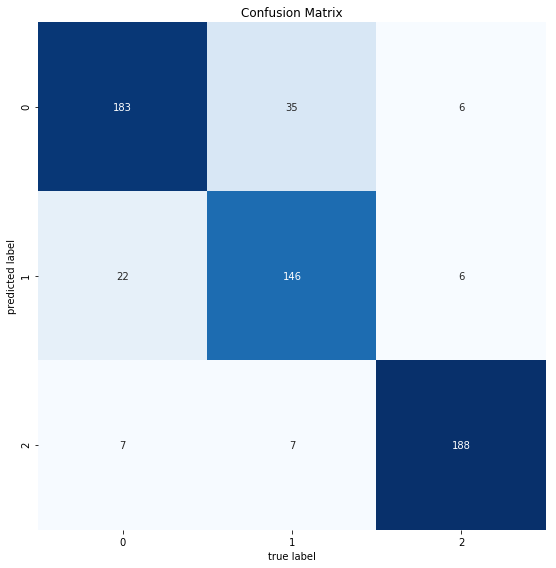

```python
from sklearn.metrics import confusion_matrix
fig, ax = plt.subplots(figsize=(8,8))         # Sample figsize in inches
mat = confusion_matrix(y_test, predicted_opt)

sb.heatmap(

    mat.T, square=True, annot=True, fmt='d', cbar=False,cmap = 'Blues',

)


plt.xlabel('true label')
plt.ylabel('predicted label')
plt.title('Confusion Matrix')
plt.tight_layout();
```

**Complications**

The biggest complication that I had in this project was scraping the data, since it was my first time. I tried to use the python library “Beautiful Soup” without much success. Then I found the python wrapper for the Genius API as mentioned earlier, that really helped me, but I had some issues. The first issue was that this takes quite a lot time to search the songs. Then, when I had started my analyses. [I found out that the some results weren’t correct. It wouldn’t always return the songs for the selected artists, for example when I tried to get the Queen songs, the API return the Beyoncé songs. In this case, I found a dataset containing the Queen songs that I concatenated with my dataset.](https://github.com/johnwmillr/LyricsGenius/issues/96)

**Reflection**

This project was really interesting and I had a lot fun doing it. Of all I learnt how to scrape the data. Then, I wanted to know how my data would look like in a word cloud. I tried to create a word cloud without preparing the data and it didn’t look very nice, for example I got a big size “Chorus” keyword since I hadn’t removed it yet. I tried to create a word cloud again but this time, I had removed those useless words like “Chorus” but the word cloud still wasn’t very nice, and I removed the verbs suffixes ("-ing", "-ed") for the algorithm to recognize the words in their root format. To accomplish this result, I used tokenization and lemmatization. (Before using the lemmatization technique, I tried stemming with PorterStemmer but I realized that WordNetLemmatizer was doing better for my dataset). I used Afinn algorithm that would return a range between -5 to +5, then based on this score I created a “feelings” column contains “positive”, “negative” or “neutral”. My initial ideal was to classify my songs using feeling, like “happy”, “angry”, “nervous”, “in love”... But I couldn’t figure out how to do that. In the first try, my predictions got a accuracy of 82%,so I dug into my dataset and I found some rock songs which were instrumental tracks with ones with lyrics. Also, as I initially had problems to scrap the data, I was running my model with 800 songs for rock, 750 for rap and 950 for country, so I added more data and I got 1000 sample for each genre, improving my model’s accuracy improved from 82% to 86% accuracy.

## Conclusion

As we expected our model did better to classify rap than country our rock. This was expected, since in your analyses we saw rap has very different words compared with rock and country. Furthermore, the rap songs are much more negative than rock and country songs.

When we compared the rock and country word clouds, we got quite similar words and the feeling of the songs is also quite similar.

For future projects, we can try to include music into the analysis, since this would be very different between rock and country.